# Asociacion de variables mediante análisis de regresión generalizado y análisis factorial multivariante

## Forest plot de modelo Firth

```
## `height` was translated to `width`.
```

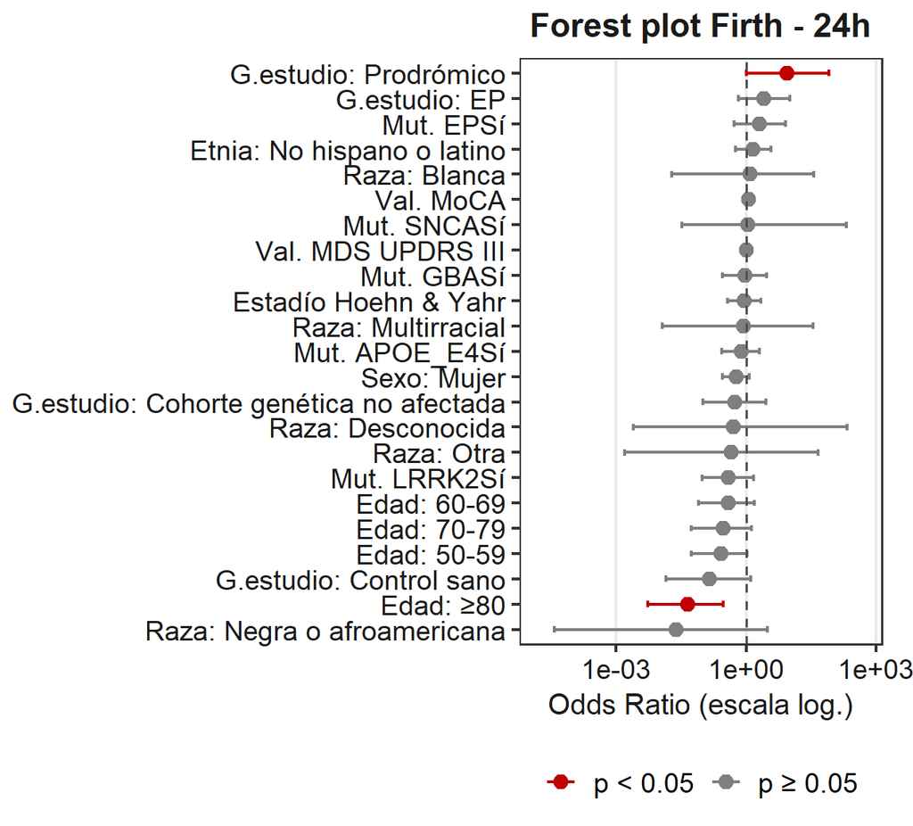

```r
forest_firth <- function(modelo, titulo = "") {

  coef_df <- data.frame(
    variable = names(coef(modelo)),
    OR       = exp(coef(modelo)),
    lower    = exp(modelo$ci.lower),
    upper    = exp(modelo$ci.upper),
    p        = modelo$prob
  ) %>%
    filter(variable != "(Intercept)") %>%
    mutate(
      significativo = ifelse(p < 0.05, "p < 0.05", "p \u2265 0.05"),
      variable = variable %>%
        gsub("`", "", .) %>%
        gsub("grupo de estudio", "G.estudio: ", .) %>%
        gsub("grupo de edad",    "Edad: ", .) %>%
        gsub("raza",  "Raza: ", .) %>%
        gsub("etnia", "Etnia: ", .) %>%
        gsub("sexoHombre", "Sexo: Hombre", .) %>%
        gsub("sexoMujer",  "Sexo: Mujer", .) %>%
        gsub("mutacion_",  "Mut. ", .) %>%
        gsub("mutación ",  "Mut. ", .) %>%
        gsub("valor ",     "Val. ", .) %>%
        gsub("Estadio Hoehn & Yahr", "Hoehn & Yahr", .) %>%
        trimws()
    ) %>%
    arrange(OR)

  ggplot(coef_df, aes(x = OR, y = reorder(variable, OR),
                      color = significativo)) +
    geom_point(size = 2.0) +
    geom_errorbarh(aes(xmin = lower, xmax = upper),
                   height = 0.25, linewidth = 0.55) +
    geom_vline(xintercept = 1, linetype = "dashed",
               color = "gray30", linewidth = 0.4) +
    scale_color_manual(
      values = c("p < 0.05" = "#C00000", "p \u2265 0.05" = "gray50"),
      name   = NULL
    ) +
    scale_x_log10(expand = expansion(mult = c(0.12, 0.12))) +
    labs(title = titulo,
         x = "Odds Ratio (escala log.)",
         y = NULL) +
    theme_bw(base_size = 10) +
    theme(
      axis.text.y        = element_text(size = 9,  color = "gray10"),
      axis.text.x        = element_text(size = 9,  color = "gray10"),
      axis.title.x       = element_text(size = 9.5, color = "gray10"),
      plot.title         = element_text(size = 11, face = "bold",
                                        hjust = 0.5, color = "gray10"),
      legend.position    = "bottom",
      legend.text        = element_text(size = 9),
      legend.key.size    = unit(0.4, "cm"),
      panel.grid.minor   = element_blank(),
      panel.grid.major.y = element_blank(),
      plot.margin        = margin(t = 4, r = 10, b = 4, l = 4)
    )
}

forest_firth(modelo_firth24, "Forest plot Firth - 24h")
```

```
## `height` was translated to `width`.
```

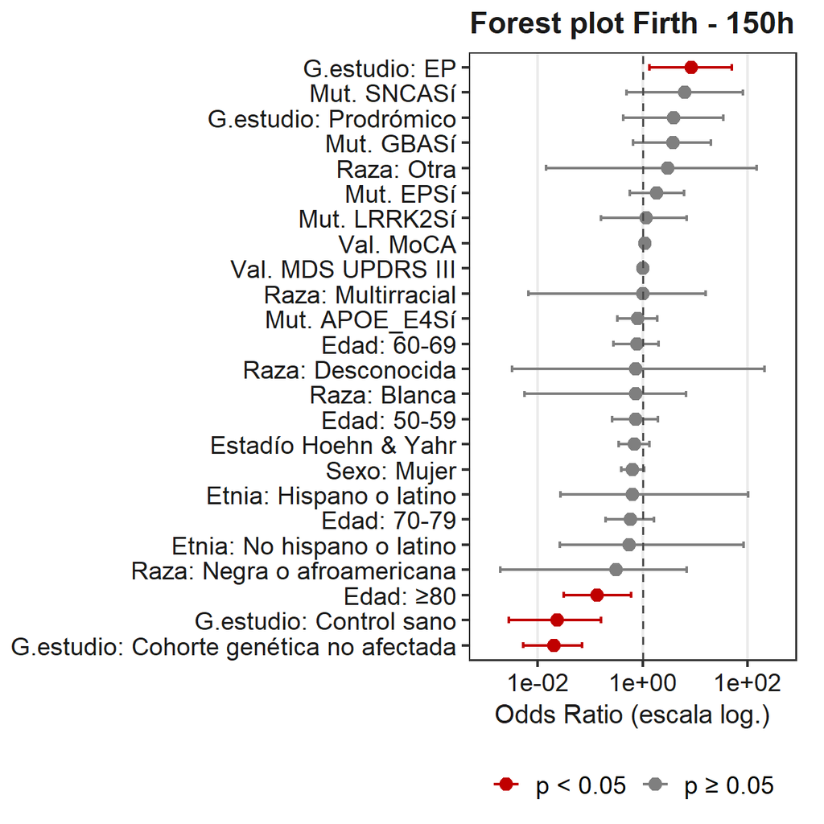

```r
forest_firth(modelo_firth150, "Forest plot Firth - 150h")
```

# Matriz de correlación de variables

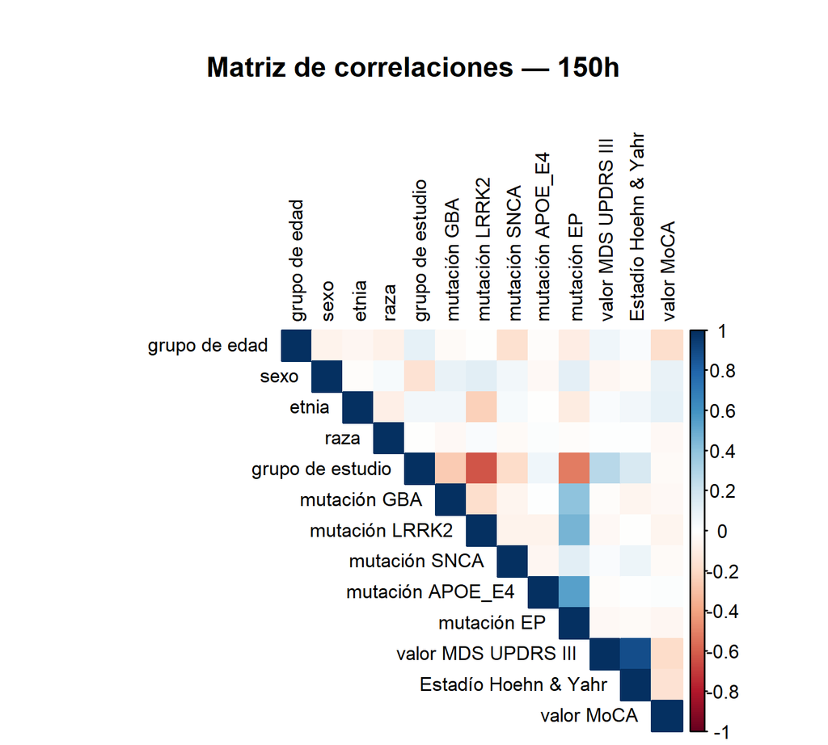

```r
# Matriz de correlación - 150h
df_150_num <- df_150 %>%
  select(-Y) %>%
  mutate(across(where(is.factor), as.numeric))

cor_150 <- cor(df_150_num, method= "spearman", use = "pairwise.complete.obs")

corrplot(cor_150, method = "color", type = "upper",
         tl.cex = 0.7, cl.cex = 0.7, tl.col = "black",
         title = "Matriz de correlaciones — 150h",
         cex.main = 1.0,
         mar = c(0, 0, 4, 0))
```

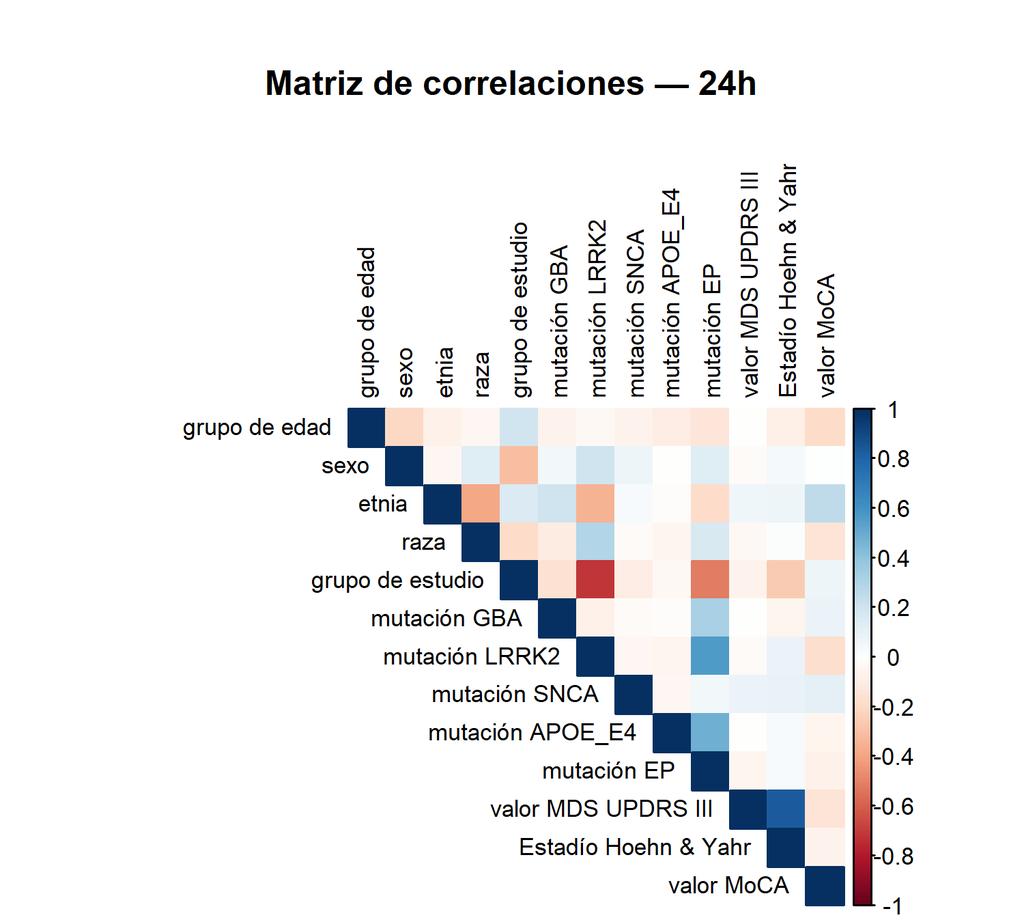

```r
# Matriz de correlación - 24h
df_24_num <- df_24 %>%
  select(-Y) %>%
  mutate(across(where(is.factor), as.numeric))

cor_24 <- cor(df_24_num, method = "spearman", use = "pairwise.complete.obs")

corrplot(cor_24, method = "color", type = "upper",
         tl.cex = 0.7, cl.cex = 0.7, tl.col = "black",
         title = "Matriz de correlaciones — 24h",
         cex.main = 1.0,
         mar = c(0, 0, 4, 0))
```

La matriz de correlación se calculó utilizando el coeficiente de correlación de Spearman, previa conversión de las variables categóricas a valores numéricos ordinales mediante as.numeric(). El coeficiente de Spearman se eligió frente a Pearson por ser más robusto ante la ausencia de normalidad y más adecuado para variables discretas y ordinales.

No obstante, es importante tener en cuenta que la conversión de variables categóricas nominales — como raza, etnia, grupo de estudio o las variables de mutación a valores numéricos mediante as.numeric() asigna números enteros a cada categoría en orden alfabético, lo cual implica asumir una relación ordinal y equidistante entre categorías que en realidad no existe. Por tanto, las correlaciones que involucren estas variables deben interpretarse con cautela y considerarse únicamente como una aproximación exploratoria. Para un análisis más riguroso de las asociaciones entre variables nominales se debería emplear la V de Cramér, mientras que para la relación entre variables numéricas y nominales lo apropiado sería la correlación biserial puntual.